[figure not shown]

# PyData Southampton News, March 2026

### 22nd Meetup, hosted by Carnival UK

### @PyDataSoton

# PyData Code of Conduct

### https://pydata.org/code-of-conduct/

[interactive chart not shown]

# NumFOCUS

- US-based charity in support of open-source scientific computing
- Financial and admin support for many open-source projects
- Support for many community events
- https://numfocus.org

[interactive chart not shown]

# PyData

- Educational program by NumFOCUS
- A global community
- 137 groups across 54 countries world-wide
- 217,861 users world-wide (+23,000 per year!)

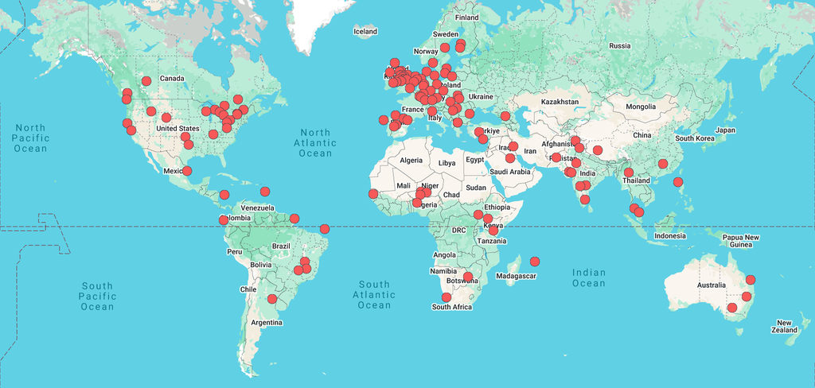

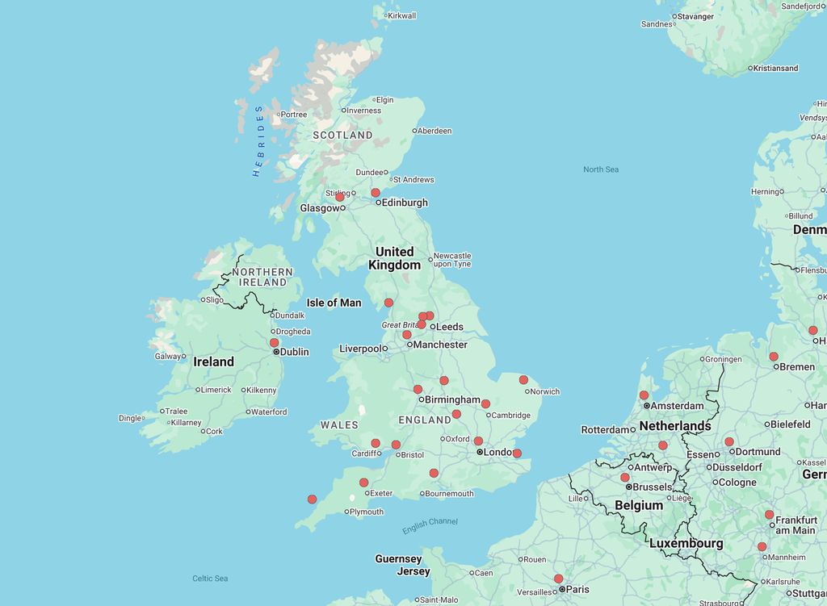

# PyData Southampton

- 728 members (~25 per month! Tell a friend! Submit a talk! Always need a ⚡)
- Monthly meetup
- All run by volunteers
- Propose a Talk: https://bit.ly/pydataSoton-talks

[figure not shown]

1. The operating company for P&O Cruises & Cunard; no one knows cruising like Carnival UK!
2. Sponsors **PyData Southampton** ❤️❤️❤️

# Upcoming Conferences

### Courtesy of https://pythondeadlin.es/

#### 🇩🇪 April 13-17 2026 - PyCon Germany & PyData Conference 2026 🚨 Programme Open 🚨

#### 🇬🇧 June 05-07 2026 - PyData London 2026 🚨 CFP Closed🚨

[interactive chart not shown]

[figure not shown]

# Tonight's Schedule

#### 18:30 Doors open

#### 19:00 Talks start ⬅️ **YOU ARE HERE**

#### 19:15 Talk #1 + Q&A

#### 19:45 Break 🥂

#### 20:00 Talk #2 + Q&A

#### 20:30 ⚡ Lightning Talks ⚡ + 📣 Community Announcements 📣

#### 20:45 to 21:00 We're done 🔜 All Bar One 🍻

### 1️⃣ Applications with Azure AI Foundry - Shubhangi Goyal

In this session, we’ll explore how Azure AI Foundry helps developers and data professionals build, customize, and operationalize AI solutions using the latest in large language models (LLMs) and Azure’s trusted infrastructure. From prompt engineering to context management, model evaluation, and deployment, we’ll walk through how the Foundry enables you to move from experimentation to production faster and more securely.

Whether you’re building copilots, domain-specific agents, or generative AI apps , this session will help you understand how Azure AI Foundry streamlines the journey from idea to impact.

Key Takeaways:

Understand the core components of Azure AI Foundry (projects, hubs, model catalog, orchestration). Learn how to integrate OpenAI and custom models into Azure-based applications. See a demo or architecture walkthrough for deploying a contextual AI app. Discover how Foundry connects with Azure Machine Learning, and AI Studio

### 2️⃣ Astronomers have too many images. What they really want is time series - Zac Irving

To study how celestial objects vary over time, astronomers need time series (measurements of an object's brightness over time). However, telescopes don't produce time series; they produce images. Astronomers therefore need software to reduce their telescope's images into time series. Unfortunately, this software exists in "pieces" with various open-source projects like photutils or source-extractor providing pieces of the image-to-time-series puzzle, but ultimately leaving gaps for astronomers to overcome. As such, it has typically up to telescope operators to write full reduction pipelines for their telescopes; this has resulted in rigid pipelines that cannot easily be applied to data from other telescopes.

## ⚡ Lightning Talks ⚡

### ⚡1️⃣ AI for Sign Language - Paul McGroary

### ⚡2️⃣ Solving the Red Ball Lottery - Adam Hill

## 🕊️ BlueSky/Thread #pydatasoton and @pydatasoton 🦆